# Caso de Estudio

# Optimización de los clasificadores

En nuestro caso: clasificación binaria, la función "cross_val_score" utiliza la validación cruzada StratifiedKFold para reducir el efecto de sesgo en los datos desequilibrados. es un buen enfoque para los casos en que la distribución de la columna de destino está sesgada

```python
def cv_check(X,y, CV):
    models = [
        RandomForestClassifier(criterion='gini',
                               n_estimators=50,
                               max_depth=11,
                               max_features=6,
                               random_state=42,
                               class_weight='balanced_subsample',
                               n_jobs=4),
        SVC(C=1, kernel='rbf', gamma='auto',random_state=42,class_weight='balanced'),
        LogisticRegression(solver='lbfgs',
                           multi_class='ovr',
                           max_iter=500,
                           C=1,
                           random_state=42,
                           class_weight='balanced'),
        GaussianNB(),
        #LinearSVC(C=1,
        #         max_iter=500,
        #          random_state=0),
        DummyClassifier(strategy='most_frequent',random_state=42)
    ]

    entries = []

    for model in models:
        Nombre_modelo = model.__class__.__name__
        print ("Currently fitting: {}".format(Nombre_modelo))
        accuracies = cross_val_score(model,
                                     X,
                                     y,
                                     scoring='roc_auc', cv=CV, n_jobs=4)
        for fold_idx, accuracy in enumerate(accuracies):
            entries.append((Nombre_modelo, fold_idx, accuracy))
        cv_df = pd.DataFrame(entries, columns=['Nombre_modelo', 'fold_idx', 'roc_auc'])

    return cv_df
```

```python
def cv_bp(cv_df, title, axes):
    axes.grid(b=True,
              which='both',
              axis='both',
              color='grey',
              linestyle = '--',
              linewidth = '0.3')
    sns.boxplot(x='Nombre_modelo',
                y='roc_auc',
                data=cv_df,
                width = 0.5,
                ax=axes,
                palette=current_palette).set_title(title)
    sns.stripplot(x='Nombre_modelo',
                  y='roc_auc',
                  data=cv_df,
                  size=5, jitter=True,
                  edgecolor="grey",
                  linewidth=1,
                  ax=axes)
    plt.ylim(0.2,1)
    plt.savefig('{}.png'.format(title), format='png')
    #plt.show()
```

```
Currently fitting: RandomForestClassifier
Currently fitting: SVC
Currently fitting: LogisticRegression
Currently fitting: GaussianNB
Currently fitting: DummyClassifier
```

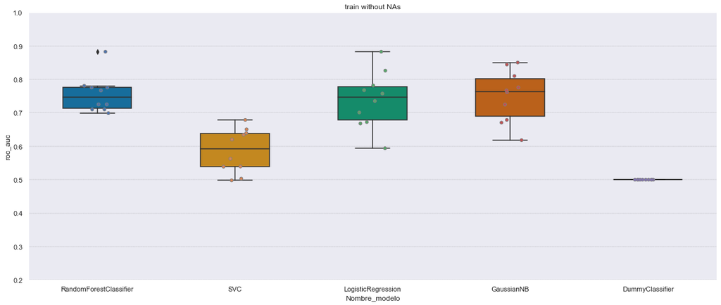

```python
f, axes = plt.subplots(1,1,figsize= (20,8),squeeze=False, sharey=True)
cv_bp(cv_check(data_set.drop(['Loan_Status'],axis=1),
               data_set.Loan_Status,10), '{} without NAs'.format('train'),axes[0,0])
```

Utilizando grid search cross validation escaneamos para encontrar los valores optimos de las variables para cada modelo. The values chosen after several runs to get the optimum variables within the optimal range for the roc_auc as closer we can get to 1

```python
X_train = data_set.drop(columns=['Loan_Status'])
y_train = data_set.iloc[:, lambda df: [False, False, False, False, False, True, False, False, False, False, False, False, False, False, False, False, False]]
```

# RandomForest

```python
def model_score(data_set, model, grid_values, scorers_list):
    X_train = data_set.drop(columns=['Loan_Status'])
    y_train = data_set['Loan_Status']

    clf_dict = {}

    for i, scorer in enumerate(scorers_list):
        clf_eval = GridSearchCV(model, param_grid=grid_values, scoring=scorer, cv=5)#, iid=False)
        clf_eval.fit(X_train,y_train)
        print('Grid best parameters for {0}: {1} scoring: {2}'
              .format(scorer, clf_eval.best_params_, round(clf_eval.best_score_,3)))
        clf_dict[scorer] = clf_eval
    return clf_dict
```

```python
grid_values = {'max_features': [4, 5, 6, 7],
              'max_depth': [3, 7, 11, 13]}
scorers_list = ['accuracy','roc_auc','precision','recall', 'f1']

rf_cv = model_score(data_set,
            RandomForestClassifier(random_state=42,
                                   n_jobs=4,
                                   class_weight='balanced_subsample',
                                   n_estimators=50),
            grid_values, scorers_list)

temp_df1 = pd.DataFrame()
for i in scorers_list:
      temp_df1[i]=rf_cv[i].cv_results_['mean_test_score'][rf_cv[i].cv_results_['param_max_features']==4]
temp_df1['max_depth'] = rf_cv['roc_auc'].cv_results_['param_max_depth'][rf_cv['roc_auc'].cv_results_['param_max_features']==4]
temp_df1.set_index('max_depth', inplace=True)
print('\n')

print('4 param max features:\n')
temp_df1

temp_df2 = pd.DataFrame()
for i in scorers_list:
      temp_df2[i]=rf_cv[i].cv_results_['mean_test_score'][rf_cv[i].cv_results_['param_max_features']==6]
temp_df2['max_depth'] = rf_cv['roc_auc'].cv_results_['param_max_depth'][rf_cv['roc_auc'].cv_results_['param_max_features']==6]
temp_df2.set_index('max_depth', inplace=True)

print('\n')
print('6param max features:\n')
temp_df2
```

```
Grid best parameters for accuracy: {'max_depth': 3, 'max_features': 6} scoring: 0.796
Grid best parameters for roc_auc: {'max_depth': 3, 'max_features': 6} scoring: 0.775
Grid best parameters for precision: {'max_depth': 7, 'max_features': 6} scoring: 0.808
Grid best parameters for recall: {'max_depth': 3, 'max_features': 5} scoring: 0.946
Grid best parameters for f1: {'max_depth': 3, 'max_features': 5} scoring: 0.864


4 param max features:
```

| max_depth | accuracy | roc_auc | precision | recall | f1 |
| --- | --- | --- | --- | --- | --- |
| 3 | 0.781250 | 0.766129 | 0.800343 | 0.912754 | 0.852409 |
| 7 | 0.783333 | 0.753481 | 0.797521 | 0.921574 | 0.854894 |
| 11 | 0.779167 | 0.742358 | 0.795214 | 0.918679 | 0.852185 |
| 13 | 0.779167 | 0.748943 | 0.795214 | 0.918679 | 0.852185 |

```
6param max features:
```

| max_depth | accuracy | roc_auc | precision | recall | f1 |
| --- | --- | --- | --- | --- | --- |
| 3 | 0.795833 | 0.775339 | 0.805947 | 0.930846 | 0.863380 |
| 7 | 0.793750 | 0.748962 | 0.807565 | 0.924695 | 0.861626 |
| 11 | 0.777083 | 0.757483 | 0.797146 | 0.912664 | 0.850289 |
| 13 | 0.791667 | 0.750357 | 0.805549 | 0.924695 | 0.860361 |

## XGBOOST

```python
def model_score(train, model, grid_values, scorers_list):
    X_train = train.drop(columns=['Loan_Status'])
    y_train = train['Loan_Status']

    clf_dict = {}

    for i, scorer in enumerate(scorers_list):
        clf_eval = GridSearchCV(model, param_grid=grid_values, scoring=scorer, cv=5)#, iid=False)
        clf_eval.fit(X_train,y_train)
        print('Grid best parameters for {0}: {1} scoring: {2}'
              .format(scorer, clf_eval.best_params_, round(clf_eval.best_score_,3)))
        clf_dict[scorer] = clf_eval
    return clf_dict
```

```python
from xgboost import XGBClassifier
```

```python
data_set['no360'] = pd.to_numeric(data_set['no360'])
y_train.Loan_Status = y_train.Loan_Status.astype('bool')
```

```python
y_train.info()
```

```
<class 'pandas.core.frame.DataFrame'>
Index: 480 entries, LP001003 to LP002990
Data columns (total 1 columns):
 #   Column       Non-Null Count  Dtype
---  ------       --------------  -----
 0   Loan_Status  480 non-null    bool
dtypes: bool(1)
memory usage: 24.2+ KB
```

```python
#PARA VER COMO ES EL MODELO.
#model = XGBClassifier(base_score=0.7,
 #                     colsample_bylevel=1,
  #                    colsample_bytree=1,gamma=0, learning_rate=0.1,
   #                   max_delta_step=0, max_depth=8,
    #   min_child_weight=1, missing=None, n_estimators=50, nthread=-1,
     #  objective='binary:logistic', reg_alpha=0, reg_lambda=1,
      # scale_pos_weight=1, seed=0, silent=True, subsample=1)

#model.fit(data_set, y_train)
```

```python
grid_values = {'n_estimators': [50, 80, 100, 150],
              'max_depth': [1, 2, 4, 6]}

scorers_list = ['accuracy','roc_auc','precision','recall', 'f1']

rf_cv = model_score(data_set,
            XGBClassifier(base_score=0.7,
                      colsample_bylevel=1,
                      colsample_bytree=1,  gamma=0, learning_rate=0.1,max_delta_step=0, min_child_weight=1, missing=None, nthread=-1,
                                   objective='binary:logistic', reg_alpha=0, reg_lambda=1,
       scale_pos_weight=1, seed=0, silent=True, subsample=1),
            grid_values, scorers_list)

temp_df1 = pd.DataFrame()

for i in scorers_list:
      temp_df1[i]=rf_cv[i].cv_results_['mean_test_score']
temp_df1['max_depth'] = rf_cv['roc_auc'].cv_results_['param_max_depth']
temp_df1.set_index('max_depth', inplace=True)
print('\n')
print('4 param max features:\n')
temp_df1

temp_df2 = pd.DataFrame()
for i in scorers_list:
      temp_df2[i]=rf_cv[i].cv_results_['mean_test_score']
temp_df2['max_depth'] = rf_cv['roc_auc'].cv_results_['param_max_depth']
temp_df2.set_index('max_depth', inplace=True)

print('\n')
print('6param max features:\n')
temp_df2
```

[output not shown]

[output not shown]

[output cut: 658 more lines]

[output not shown]

[output not shown]

[output not shown]

[output not shown]

[output not shown]

[output not shown]

[output not shown]

[output not shown]

[output not shown]

[output not shown]

[output not shown]

[output not shown]

[output not shown]

[output not shown]

[output not shown]

[output not shown]

[output not shown]

[output not shown]

[output not shown]

[output not shown]

[output not shown]

[output not shown]

[output not shown]

[output not shown]

[output not shown]

[output cut: 745 more lines]

[output not shown]

[output not shown]

[output cut: 646 more lines]

[output not shown]

[output not shown]

[output cut: 652 more lines]

[output not shown]

| max_depth | accuracy | roc_auc | precision | recall | f1 |
| --- | --- | --- | --- | --- | --- |
| 1 | 0.806250 | 0.776239 | 0.793031 | 0.975893 | 0.874712 |
| 1 | 0.806250 | 0.780052 | 0.793031 | 0.975893 | 0.874712 |
| 1 | 0.806250 | 0.779914 | 0.793031 | 0.975893 | 0.874712 |
| 1 | 0.804167 | 0.774511 | 0.792457 | 0.972863 | 0.873173 |
| 2 | 0.806250 | 0.758302 | 0.794679 | 0.972863 | 0.874436 |
| 2 | 0.802083 | 0.760570 | 0.797791 | 0.957802 | 0.870228 |
| 2 | 0.808333 | 0.757821 | 0.805763 | 0.954817 | 0.873541 |
| 2 | 0.797917 | 0.751357 | 0.805270 | 0.936771 | 0.865419 |
| 4 | 0.789583 | 0.744883 | 0.796911 | 0.936816 | 0.860588 |
| 4 | 0.770833 | 0.746858 | 0.792243 | 0.909634 | 0.846205 |
| 4 | 0.772917 | 0.745213 | 0.797130 | 0.903618 | 0.846477 |
| 4 | 0.762500 | 0.745405 | 0.797151 | 0.882497 | 0.836988 |
| 6 | 0.770833 | 0.751951 | 0.791950 | 0.909769 | 0.846042 |
| 6 | 0.766667 | 0.748115 | 0.802063 | 0.882587 | 0.839761 |
| 6 | 0.766667 | 0.747227 | 0.801577 | 0.882587 | 0.839663 |
| 6 | 0.758333 | 0.746693 | 0.799614 | 0.870511 | 0.833026 |

```
6param max features:
```

| max_depth | accuracy | roc_auc | precision | recall | f1 |
| --- | --- | --- | --- | --- | --- |
| 1 | 0.806250 | 0.776239 | 0.793031 | 0.975893 | 0.874712 |
| 1 | 0.806250 | 0.780052 | 0.793031 | 0.975893 | 0.874712 |
| 1 | 0.806250 | 0.779914 | 0.793031 | 0.975893 | 0.874712 |
| 1 | 0.804167 | 0.774511 | 0.792457 | 0.972863 | 0.873173 |
| 2 | 0.806250 | 0.758302 | 0.794679 | 0.972863 | 0.874436 |
| 2 | 0.802083 | 0.760570 | 0.797791 | 0.957802 | 0.870228 |
| 2 | 0.808333 | 0.757821 | 0.805763 | 0.954817 | 0.873541 |
| 2 | 0.797917 | 0.751357 | 0.805270 | 0.936771 | 0.865419 |
| 4 | 0.789583 | 0.744883 | 0.796911 | 0.936816 | 0.860588 |
| 4 | 0.770833 | 0.746858 | 0.792243 | 0.909634 | 0.846205 |
| 4 | 0.772917 | 0.745213 | 0.797130 | 0.903618 | 0.846477 |
| 4 | 0.762500 | 0.745405 | 0.797151 | 0.882497 | 0.836988 |
| 6 | 0.770833 | 0.751951 | 0.791950 | 0.909769 | 0.846042 |
| 6 | 0.766667 | 0.748115 | 0.802063 | 0.882587 | 0.839761 |
| 6 | 0.766667 | 0.747227 | 0.801577 | 0.882587 | 0.839663 |
| 6 | 0.758333 | 0.746693 | 0.799614 | 0.870511 | 0.833026 |

## LogisticRegression

```python
grid_values = {'C': [0.01, 0.1, 1, 10, 100],
              'penalty': ['l1', 'l2']}
scorers_list = ['accuracy','roc_auc','precision','recall', 'f1']


lr_cv = model_score(data_set,
                    LogisticRegression(solver='liblinear',random_state=42, max_iter=500,
                                      class_weight='balanced'),
                    grid_values,
                    scorers_list)

#1
temp_df1 = pd.DataFrame()

for i in scorers_list:
      temp_df1[i]=lr_cv[i].cv_results_['mean_test_score'][lr_cv[i].cv_results_['param_penalty']=='l1']

temp_df1['C'] = lr_cv['roc_auc'].cv_results_['param_C'][lr_cv['roc_auc'].cv_results_['param_penalty']=='l1']
temp_df1.set_index('C', inplace=True)

print('l1:\n')
temp_df1

#2
temp_df2 = pd.DataFrame()

for i in scorers_list:
      temp_df2[i]=lr_cv[i].cv_results_['mean_test_score'][lr_cv[i].cv_results_['param_penalty']=='l2']

temp_df2['C'] = lr_cv['roc_auc'].cv_results_['param_C'][lr_cv['roc_auc'].cv_results_['param_penalty']=='l2']
temp_df2.set_index('C', inplace=True)
print('l2:\n')
temp_df2
```

```
Grid best parameters for accuracy: {'C': 0.1, 'penalty': 'l1'} scoring: 0.779
Grid best parameters for roc_auc: {'C': 10, 'penalty': 'l1'} scoring: 0.745
Grid best parameters for precision: {'C': 0.1, 'penalty': 'l2'} scoring: 0.804
Grid best parameters for recall: {'C': 0.1, 'penalty': 'l1'} scoring: 0.931
Grid best parameters for f1: {'C': 0.1, 'penalty': 'l1'} scoring: 0.853
l1:
```

| C | accuracy | roc_auc | precision | recall | f1 |
| --- | --- | --- | --- | --- | --- |
| 0.01 | 0.504167 | 0.514547 | 0.686963 | 0.515332 | 0.586395 |
| 0.10 | 0.779167 | 0.675626 | 0.789056 | 0.930891 | 0.853057 |
| 1.00 | 0.725000 | 0.742081 | 0.796591 | 0.813433 | 0.803539 |
| 10.00 | 0.712500 | 0.744538 | 0.796245 | 0.789462 | 0.790915 |
| 100.00 | 0.712500 | 0.743631 | 0.794817 | 0.792492 | 0.791554 |

```
l2:
```

| C | accuracy | roc_auc | precision | recall | f1 |
| --- | --- | --- | --- | --- | --- |
| 0.01 | 0.706250 | 0.655999 | 0.782809 | 0.795749 | 0.787023 |
| 0.10 | 0.741667 | 0.731795 | 0.803648 | 0.831434 | 0.816663 |
| 1.00 | 0.727083 | 0.742079 | 0.800631 | 0.810448 | 0.804365 |
| 10.00 | 0.718750 | 0.744025 | 0.799671 | 0.795477 | 0.795795 |
| 100.00 | 0.714583 | 0.743934 | 0.795495 | 0.795522 | 0.793399 |

# SVC

```python
grid_values = {'C': [1, 10],
              'gamma': [0.5, 0.7, 0.9, 0.95]}
scorers_list = ['accuracy','roc_auc','precision','recall', 'f1']


svc_cv = model_score(data_set,
                    SVC(random_state=42, class_weight='balanced',kernel='rbf'),
                    grid_values,
                    scorers_list)


temp_df1 = pd.DataFrame()
for i in scorers_list:
      temp_df1[i]=svc_cv[i].cv_results_['mean_test_score'][svc_cv[i].cv_results_['param_C']==1]
temp_df1['gamma'] = svc_cv['roc_auc'].cv_results_['param_gamma'][svc_cv['roc_auc'].cv_results_['param_C']==1]
temp_df1.set_index('gamma', inplace=True)
print('C=1:\n')
temp_df1

temp_df2 = pd.DataFrame()
for i in scorers_list:
      temp_df2[i]=svc_cv[i].cv_results_['mean_test_score'][svc_cv[i].cv_results_['param_C']==10]
temp_df2['gamma'] = svc_cv['roc_auc'].cv_results_['param_gamma'][svc_cv['roc_auc'].cv_results_['param_C']==10]
temp_df2.set_index('gamma', inplace=True)
print('C=10:\n')
temp_df2
```

```
Grid best parameters for accuracy: {'C': 1, 'gamma': 0.9} scoring: 0.683
Grid best parameters for roc_auc: {'C': 1, 'gamma': 0.95} scoring: 0.552
Grid best parameters for precision: {'C': 1, 'gamma': 0.9} scoring: 0.689
Grid best parameters for recall: {'C': 1, 'gamma': 0.9} scoring: 0.988
Grid best parameters for f1: {'C': 1, 'gamma': 0.9} scoring: 0.812
C=1:
```

| gamma | accuracy | roc_auc | precision | recall | f1 |
| --- | --- | --- | --- | --- | --- |
| 0.50 | 0.679167 | 0.549213 | 0.687663 | 0.981818 | 0.808816 |
| 0.70 | 0.681250 | 0.544049 | 0.688335 | 0.984848 | 0.810306 |
| 0.90 | 0.683333 | 0.551263 | 0.689021 | 0.987879 | 0.811816 |
| 0.95 | 0.683333 | 0.551682 | 0.689021 | 0.987879 | 0.811816 |

```
C=10:
```

| gamma | accuracy | roc_auc | precision | recall | f1 |
| --- | --- | --- | --- | --- | --- |
| 0.50 | 0.679167 | 0.549322 | 0.687663 | 0.981818 | 0.808816 |
| 0.70 | 0.681250 | 0.548944 | 0.688335 | 0.984848 | 0.810306 |
| 0.90 | 0.683333 | 0.551571 | 0.689021 | 0.987879 | 0.811816 |
| 0.95 | 0.683333 | 0.551480 | 0.689021 | 0.987879 | 0.811816 |

The following are the main functions to run each model evaluation in the chosen best values

```python
def mod_eval(df,predictions, predprob, y_test, title):
    # prints confusion matrix heatmap
    cm = confusion_matrix(df.Loan_Status[y_test.index], predictions)
    sns.heatmap(cm, annot=True, fmt='.3g', xticklabels=['No', 'Yes'], yticklabels=['No', 'Yes']).set_title(title)
    plt.xlabel('Real')
    plt.ylabel('Predict')

    print(classification_report(df.Loan_Status[y_test.index], predictions))

    f, axes = plt.subplots(1,2,figsize= (20,6),squeeze=False)

    fpr, tpr, _ = roc_curve(df.Loan_Status[y_test.index], predprob[:,1])
    roc_auc = auc(fpr,tpr)
    axes[0,0].plot(fpr, tpr, lw=3)
    axes[0,0].set_title('{} ROC curve (area = {:0.2f})'.format(title, roc_auc))
    axes[0,0].set(xlabel='False Positive Rate',ylabel='True Positive Rate')
    axes[0,0].grid(b=True, which='both', axis='both', color='grey', linestyle = '--', linewidth = '0.3')

    precision, recall, thresholds = precision_recall_curve(y_test, predprob[:,1])
    best_index = np.argmin(np.abs(precision-recall)) # set the best index to be the minimum delta between precision and recall
    axes[0,1].plot(precision,recall)
    axes[0,1].set_title('{} Precision-Recall Curve'.format(title))
    axes[0,1].set(xlabel='Precision', ylabel='Recall', xlim=(0.4,1.05))
    axes[0,1].plot(precision[best_index],recall[best_index],'o',color='r')
    axes[0,1].grid(b=True, which='both', axis='both', color='grey', linestyle = '--', linewidth = '0.3')
def model_training(classifier,df):
    clf = classifier
    t=df.drop(columns=['Loan_Status'])
    X_train, X_test, y_train, y_tests = train_test_split(t,
                                                         df['Loan_Status'],
                                                         test_size=ts,
                                                         stratify=df['Loan_Status'])
    clf.fit(X_train, y_train)
    return clf
```

```python
#RandomForest
max_depth=11
max_features=5
```

```python
#LogisticRegression
lr_C=0.1
penalty='l1'
```

```python
#SVC
svc_C=1
gamma=0.9
```

```python
#Test Size
ts = 0.333
```